# Data science challenge

[figure not shown]

The competition will take place in the Data Science challenges platform, which is available at the following link:

https://data-science-challenges.unibocconi.it

You must login with your credentials to enter the competition. There you will find a copy of the training and test datasets. However, a copy of the data is also available on the github repository and can be downloaded using the code provided in this notebook.

## Dataset

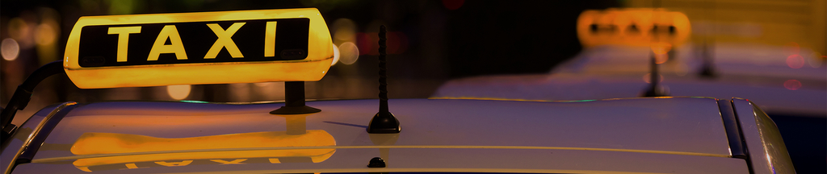

The dataset is sourced from the [NYC Taxi and Limousine Commission](https://www.nyc.gov/site/tlc/index.page). Each observation corresponds to a ride taken in a yellow taxi cab. Although data for billions of rides across several years are available, we will focus on a subset of data from May 2015. The **raw data** has been partially **cleaned and merged** with spatial data from the [NYC Department of City Planning](https://www.nyc.gov/site/planning/index.page).

The data has been **filtered** to include only transactions paid for with a credit card. Variables include the hour and day of the week the cab was picked up, neighborhood codes for the neighborhood tabulation area where the cab was picked up, and the neighborhood where the passenger was dropped off.

## Assignment rules and evaluation criteria

The variable of interest is the **tip amount** (`response` variable), i.e. the amount tipped to the driver.

Submissions are evaluated using the **Mean Absolute Error (MAE)** between the predicted response and the observed target (`response`), that is

$$\text{MAE} = \frac{1}{n}\sum_{i=1}^{n} |y_i - \hat{y}_i |.$$
In this competition you will be evaluated on the basis of:

- A **.pdf report (at most 3 pages)** that you will need to enclose in the data competition platform before the deadline;
- The **MAE score** on the private leaderboard. Please note that only the **last** submission is evaluated.

The training, the public and the private datasets correspond to roughly the 30%, 10% and 60% of the original data. These subsets have been randomly sampled.

The winning team, based on the score, will present their work in class.

## Columns

A data dictionary of the raw dataset is [available here](https://www.nyc.gov/assets/tlc/downloads/pdf/data_dictionary_trip_records_yellow.pdf). Below, you can find a description of the actual columns. The raw data and further documentation can be found at [this link](https://www.nyc.gov/site/tlc/about/tlc-trip-record-data.page).

- `response` : The response variable, i.e. the tip amount in US dollars
- `weight` : constant variable that can be removed because the evaluation score is not weighted
- `pickup_hour`: Hour of the pick-up
- `pickup_month`: Month of the pick-up (always May)
- `pickup_week`: Week of the pick-up
- `pickup_doy`: Day of the year of the pick-up (from 1 to 365)
- `pickup_wday`: Day of the week of the pick-up (from 1 to 7)
- `length_time`: Duration of the ride (in seconds)
- `pickup_BoroCode`: Macro-area of the pick-up
- `pickup_NTACode`: Micro-area of the pick-up (Neighborhood Tabulation Areas)
- `dropoff_BoroCode`: Macro-area of the drop-off
- `dropoff_NTACode`: Micro-area of the drop-off (Neighborhood Tabulation Areas)
- `pickup_longitude`: Longitude of the pick-up
- `pickup_latitude`: Latitude of the pick-up
- `dropoff_longitude`: Longitude of the drop-off
- `dropoff_latitude`: Latitude of the drop-off
- `vendor_id`: The TPEP provider that provided the record
- `passenger_count`: The number of passengers in the vehicle. This is a driver-entered value.
- `trip_distance`: The elapsed trip distance in miles reported by the taximeter
- `fare_amount`: The time-and-distance fare calculated by the meter
- `pair`: Combination of the variables `pickup_NTACode` and `dropoff_NTACode`

## Import the data

You can either download the data from the https://data-science-challenges.unibocconi.it platform or you can use the following code.

```python
# Import basic libraries
import pandas as pd
import numpy as np
```

```python
# The training dataset comprises 147307 rows and 21 columns
taxi = pd.read_csv("https://datasciencebocconi.github.io/Data/taxi_train.csv")

# The training dataset comprises 343985 rows and 19 columns (the label `response` is not available)
taxi_pred = pd.read_csv("https://datasciencebocconi.github.io/Data/taxi_test.csv")

# Let's have a look at the training dataset
taxi
```

|  | weight | response | pickup_hour | pickup_month | pickup_week | pickup_doy | pickup_wday | length_time | pickup_BoroCode | pickup_NTACode | ... | dropoff_NTACode | pickup_longitude | pickup_latitude | dropoff_longitude | dropoff_latitude | vendor_id | passenger_count | trip_distance | fare_amount | pair |
| --- | --- | --- | --- | --- | --- | --- | --- | --- | --- | --- | --- | --- | --- | --- | --- | --- | --- | --- | --- | --- | --- |
| 0 | 1 | 1.70 | 7 | 5 | 21 | 146 | 4 | 672 | 1 | MN24 | ... | MN17 | -74.009789 | 40.712395 | -73.983223 | 40.760330 | 1 | 1 | 3.70 | 12.5 | MN24-MN17 |
| 1 | 1 | 1.00 | 2 | 5 | 22 | 148 | 6 | 637 | 1 | MN17 | ... | MN33 | -73.978989 | 40.755726 | -73.951187 | 40.789021 | 1 | 1 | 3.40 | 12.0 | MN17-MN33 |
| 2 | 1 | 1.56 | 22 | 5 | 22 | 148 | 6 | 426 | 1 | MN21 | ... | MN17 | -73.980827 | 40.738148 | -73.984062 | 40.747284 | 1 | 1 | 0.90 | 6.5 | MN21-MN17 |
| 3 | 1 | 2.46 | 7 | 5 | 18 | 125 | 4 | 912 | 1 | MN50 | ... | MN17 | -73.977333 | 40.733997 | -73.987267 | 40.750458 | 2 | 1 | 1.96 | 11.5 | MN50-MN17 |
| 4 | 1 | 2.06 | 18 | 5 | 20 | 134 | 6 | 578 | 1 | MN34 | ... | MN09 | -73.940514 | 40.793331 | -73.961418 | 40.806286 | 2 | 1 | 1.78 | 8.5 | MN34-MN09 |
| ... | ... | ... | ... | ... | ... | ... | ... | ... | ... | ... | ... | ... | ... | ... | ... | ... | ... | ... | ... | ... | ... |
| 147302 | 1 | 2.70 | 9 | 5 | 21 | 144 | 2 | 824 | 1 | MN17 | ... | MN15 | -73.979660 | 40.761322 | -74.001076 | 40.762772 | 1 | 2 | 1.50 | 10.0 | MN17-MN15 |
| 147303 | 1 | 4.00 | 0 | 5 | 18 | 123 | 2 | 1106 | 4 | QN98 | ... | BK77 | -73.872276 | 40.774151 | -73.923759 | 40.701000 | 2 | 2 | 8.81 | 25.5 | QN98-BK77 |
| 147304 | 1 | 1.36 | 20 | 5 | 22 | 148 | 6 | 237 | 1 | MN24 | ... | MN23 | -74.008476 | 40.718956 | -74.006294 | 40.733479 | 2 | 1 | 1.03 | 5.5 | MN24-MN23 |
| 147305 | 1 | 3.55 | 17 | 5 | 21 | 147 | 5 | 1395 | 1 | MN19 | ... | MN24 | -73.970459 | 40.758743 | -73.997932 | 40.725746 | 1 | 1 | 2.90 | 16.0 | MN19-MN24 |
| 147306 | 1 | 2.50 | 7 | 5 | 19 | 128 | 7 | 810 | 1 | MN31 | ... | MN13 | -73.955627 | 40.764088 | -74.002502 | 40.739761 | 2 | 1 | 4.12 | 14.5 | MN31-MN13 |

147307 rows × 21 columns

## Submit a prediction

```python
# Consider here a couple of variables variable
X = taxi[['pickup_hour', 'fare_amount']]
X_pred  = taxi_pred[['pickup_hour', 'fare_amount']]

# Here we create the numeric outcome
y = taxi["response"]
```

```python
# Import a naive Bayes function
from sklearn.linear_model import LinearRegression

# Fit a naive Bayes Classifier
m_lin = LinearRegression()

# Fit the logistic regression model
m_lin.fit(X, y)

# Predict values on the prediction set
y_lin_pred = m_lin.predict(X_pred)
y_lin_pred
```

```
array([7.62942643, 2.21783555, 3.67738345, ..., 2.17204522, 2.57852821,
       1.72089791])
```

```python
export_pred = pd.DataFrame(y_lin_pred, columns = ['response'])

# The header and the index are removed as this is required by the platform
export_pred.to_csv('lin_pred.txt', index = False, header = False)
```

Look for the `lin_pred.txt` file that has been created in your computer and / or download it from Google Colab. Of course you can name the file as you wish, perhaps with some name that reminds you the chosen method.

Then, you can upload the file to the platform https://data-science-challenges.unibocconi.it and see how you scored on the partial leaderboard.

# Let the challenge begin!

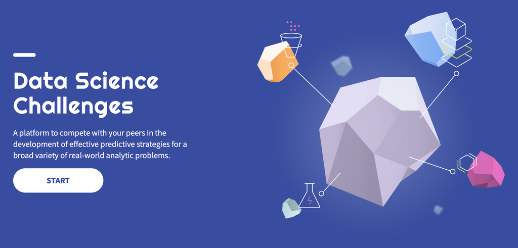